# Measuring Flow Speed and Flow Depth of the Aare River

# A Step by Step Manual to Recreate our Sensors

## The Water Wheel

To measure flow speed we created a small but reliable water wheel, which measures RPM via a reed sensor and saves the measurements on a local SD-card. The construction is simple, cheap, and fast.

### Bulding the Wheel

The complete water wheel consists of four main parts: the wheel itself, the floaters, the reed sensor, and connecting tiles, holding everything in place. The wheel is made of a synthetic plastic. It needs to be cut out in two disks with a radius of r = 12 cm. The eight shovels are simple 6 x 6 cm squares, made out of the same material. Before assembling the wheel, three holes with a diameter of d = 5 mm need to be drilled into the disks. One each in the disks’ centers and one approximately 1 cm from one of the disk’s edges - later, the magnet triggering the reed sensor will be installed there. Centered on the center holes, one plastic bearing with a 5 mm hole needs to be glued onto each disc. This is done most effectively with hot glue. Now, the wheel can be assembled. Using more hot glue, the eight shovels are glued to one of the disks. Afterwards, the other disk is glued on to finish the wheel. Into the prepared hole, a magnet with a diameter of 5 mm is placed and fixed in place with hot glue. The floaters are two wooden cuboids of a length of approximately 30 cm and a base of approximately 6 x 6 cm. Per cuboid, there need to be two wooden hinges. One part is fixed to the cuboid, the other is attached to the fixed part with a screw and movable. The movable part needs to be drilled with six 5 mm holes from the outermost edge towards the inside in 1 cm increments. The fixed part of the hinge is approximately 6 x 2 cm and the movable part 12 x 2 cm. These holes allow for variable vertical and horizontal placement of the water wheel in relation to the floaters and, ultimately, to the water surface. The reed sensor - its exact composition is described in the following chapter “Building the Hardware” - is hot glued onto a piece of wood, measuring the diameter of the water wheel in length and approximately 3 cm in width. A 5 mm hole is drilled at its other end. An axle with a diameter of 5 mm and a length of approximately 25 cm needs to be prepared. One by one, the first hinge (with the attached floater), the reed sensor, the water wheel, and the second hinge-floater-contraption need to be slid onto the axle. To increase its stability, two metal rods are mounted on both sides, connecting the otherwise separate floaters.

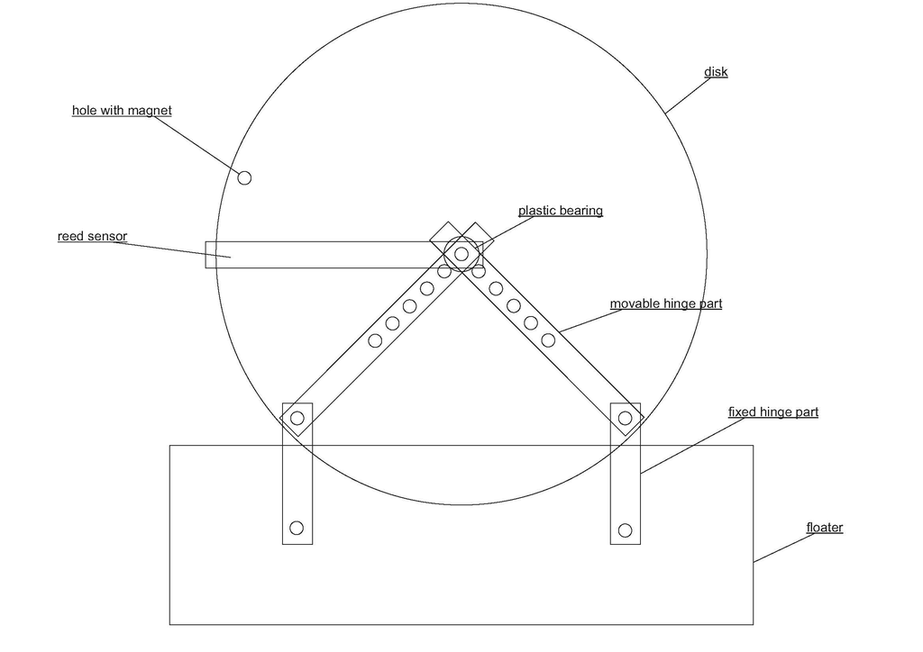

Figure 1: The Water Wheel (created by authors)

### Building the Hardware

The hardware to the water wheel is very simple. A reed switch needs to be soldered between two cables which have pins on their other sides. These pins are plugged into the arduino, which is powered by a 12V battery, connected to a voltage converter board that provides a 5V USB output.

### Building the Software

#### Basics

The very basics of the software are simple, as the Arduino only has to sense when the two wires connected to the reed sensor and a ground and data pin are bridged. In practice, this also requires implementing a debounce of 50ms, meaning that if the pins disconnect and are bridged again within 50ms, only one pulse will be counted to avoid erroneous inputs when the reed switch quickly bounces between states as the magnet passes by.

#### Data storage

The Arduino saves the following to the SD-Card: A running counter for each measurement, the real-time timestamp for each measurement, the number of pulses during that one-minute interval and the total number of pulses since starting the measurement. The data is saved in a CSV file.

#### Display output

For easy troubleshooting, the OLED display on the Arduino was configured to display the following: The number of pulses in the current interval, the RPM from the last two pulses, the time until the next interval and the estimated flow velocity taking into account the radius and efficiency of the wheel.

#### Communication with second Arduino

Due to time constraints, the pressure sensor data was measured and saved with a second Arduino. To ensure that both Arduinos save their data points at the exact same moment, whenever an interval is done and the data is saved, it also sets pin D3 high, which the second Arduino is listening for and then also saves the pressure data. This also required the ground pins on both to be connected.

#### Interrupts

As the signal from the reed switch is irregular and unpredictable, a hardware interrupt was used so that a signal from the switch takes priority over any other task, ensuring that no signals are missed due to updating the screen.

## The Depth Sensor

### Building the Depth Sensor

While the pressure sensor comes as a complete unit, powering it and measuring the values from it is a bit more involved than just connecting it to the Arduino and reading the signal. The sensor comes on a long cable that includes a pressure relief tube inside it, so it automatically accounts for changes in ambient pressure.

### Building the Hardware

#### Interference/Crosstalk/Grounding problem

When the voltage converter board for the Arduino and the pressure sensor 12V power are both connected to the same battery, this causes an issue in that the pressure reported is always around 65cm too deep and the signal fluctuates. We were not able to find out exactly what causes that problem, but an easy solution was to just install a second battery that only powers the pressure sensor. Using a galvanically isolated DC-DC-converter would likely also solve the problem while only requiring one battery.

### Building the Software

#### Basics

At its core, the Arduino converts the voltage data received over I2C back to the current and then applies the linear relationship between it and depth to calculate the latter. This requires setting the possible current range (4-20mA in our case) and the maximum depth (5m in our case). Optionally, the water density can also be set.

#### Data storage

The Arduino saves the following to the SD-Card: A running counter for each measurement, the real-time timestamp for each measurement, the voltage from the converter, the current in the circuit and the water depth. The data is saved in a CSV file.

#### Display output

For easy troubleshooting, the OLED display on the Arduino was configured to display the following: The last measurement index, the time since the last signal from the other Arduino and the live voltage, current and depth data.

#### Communication with second Arduino

To ensure synchronised data points, the Arduino waits for pin D3 to receive the signal from the other one and saves the data to the SD card whenever it is received. The signal was never missed in our testing, but if that were to happen, the inclusion of the timestamp in both datasets would allow for a nearest-neighbour-algorithm so resync the two datasets.

#### Interrupts

As the signal from the other Arduino is not perfectly predictable (RTC drifting), a hardware interrupt was used so that it takes priority over any other task, ensuring that no signals are missed due to updating the screen.

## Compiling the Sensors’ Hardware and Installing them in a Stream

### Water wheel

The water wheel can be tied to any fixed object above the water level with two strings going to eyelet screws on the floats. In our case we attached it to a downed tree lying in the water, but pieces of rebar sticking out would work too. The flow direction should be relatively consistent as the wheel may overturn otherwise. Different positions of the screws on the floats can affect how the wheel sits in the water - ideally, it is perfectly level.

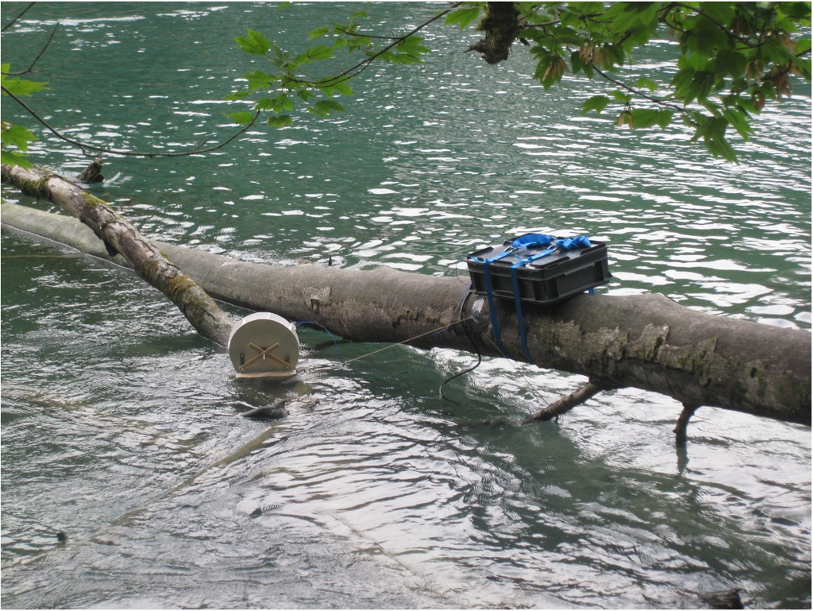

Figure 2: The complete installation (taken by authors)

### Pressure sensor

The pressure sensor was attached to a piece of rebar with zipties and this was then hammered into the ground. The position of the pressure sensor should be as close to the wheel as possible, but ideally downstream so it does not negatively affect flow.

### Power and Arduinos

The Arduinos, batteries and all the voltage and signal converters were installed on a piece of foam board that fits inside a RAKO box with cover. The wires were fed out through waterproof bungs. This box can be installed anywhere the wires reach, with the wire of the pressure sensor theoretically being the limiting factor. The box was attached to the same downed tree with two ratchet straps.

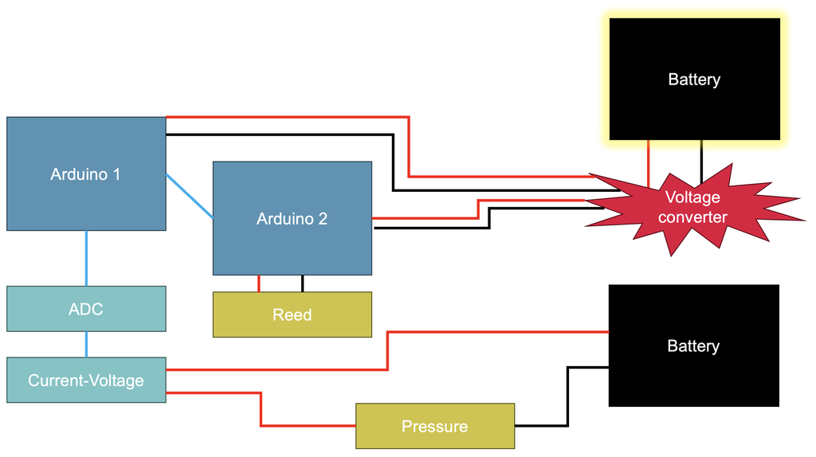

Figure 3: Schematic of the wiring in the box (created by authors)

[figure not shown]

Figure 4: The internals of the box (taken by authors)

## List of materials required

### Arduinos

| Amount | Item |
| --- | --- |
| 2 | Seeeduino Xiao |
| 2 | Seeeduino expansion boards |
| 2 | USB-A to USB-C power cables |

### Power

| Amount | Item |
| --- | --- |
| 2 | 12V batteries |
| 1 | 12V Fuse block |
| 2 | 3A Fuses |
| 1 | DfRobot DFR0580 Solar Power Manager |

### Water wheel

| Amount | Item |
| --- | --- |
|  | General wood pieces and screws for the frame |
|  | Foam board for the water wheel |
| 1 | Hot glue gun |
|  | Magnet |
| 1 | Reed switch |
| 2 | Wires and pins |
| 2 | Eyelet screws |
| 2 | Metal rods and mounts for stability |

### Pressure sensor

| Amount | Item |
| --- | --- |
| 1 | DfRobot KIT0139 Pressure sensor |
| 1 | SEN0262 Current-Voltage-Converter |
| 1 | ADS1115 ADC |

### Waterproofing / Mounting

| Amount | Item |
| --- | --- |
|  | Wires/pins for internal connections |
| 1 | RAKO box with cover |
| 2 | Waterproof bungs for the wires |
| 1 | Piece of rebar and zipties for pressure sensor |
|  | String for attaching water wheel |
| 2 | Straps for mounting the box |

## Data analysis in R

### Import the CSV files from the SD cards, combine them, format the timestamps and plot the initial data:

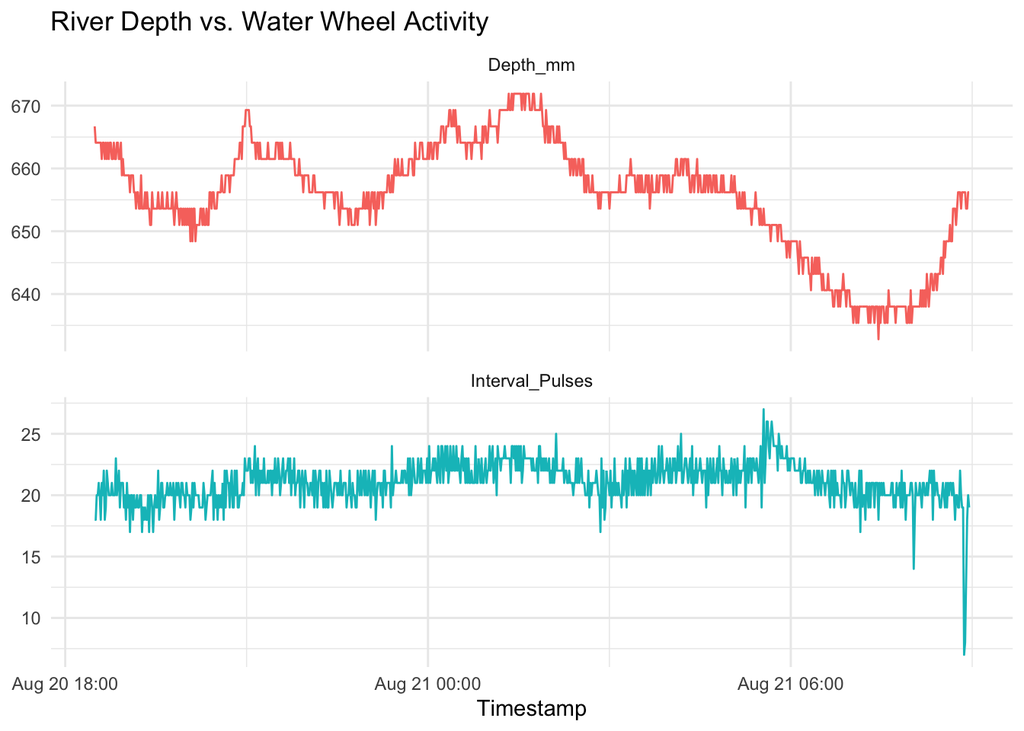

```r
library(tidyverse)
library(lubridate)
library(slider)
library(hexbin)
library(usethis)
library(gitcreds)
library(broom)

#Read CSV files
reed <- read.csv(file = "DATALOG.CSV", header = TRUE)
press <- read.csv(file = "PRESSLOG.CSV", header = TRUE)

data <- cbind(reed, press[3:5])

data <- data %>% #Mutate timestamps
  mutate(Timestamp = ymd_hms(Timestamp) + hours(5) + minutes(14) + seconds(52))

data <- data[-c(1:151, 1021:1024), ]

data$Speed <- data$Interval_Pulses*pi*24/100/60

# Pivot long and create stacked line charts
data %>%
  pivot_longer(cols = c(Interval_Pulses, Depth_mm),
               names_to = "Metric",
               values_to = "Value") %>%
  ggplot(aes(x = Timestamp, y = Value, color = Metric)) +
  geom_line(show.legend = FALSE) +
  facet_wrap(~ Metric, scales = "free_y", ncol = 1) +
  labs(
    title = "River Depth vs. Water Wheel Activity",
    x = "Timestamp",
    y = NULL
  ) +
  theme_minimal()
```

### Create 10min smoothed versions of the data and plot for a cleaner appearance:

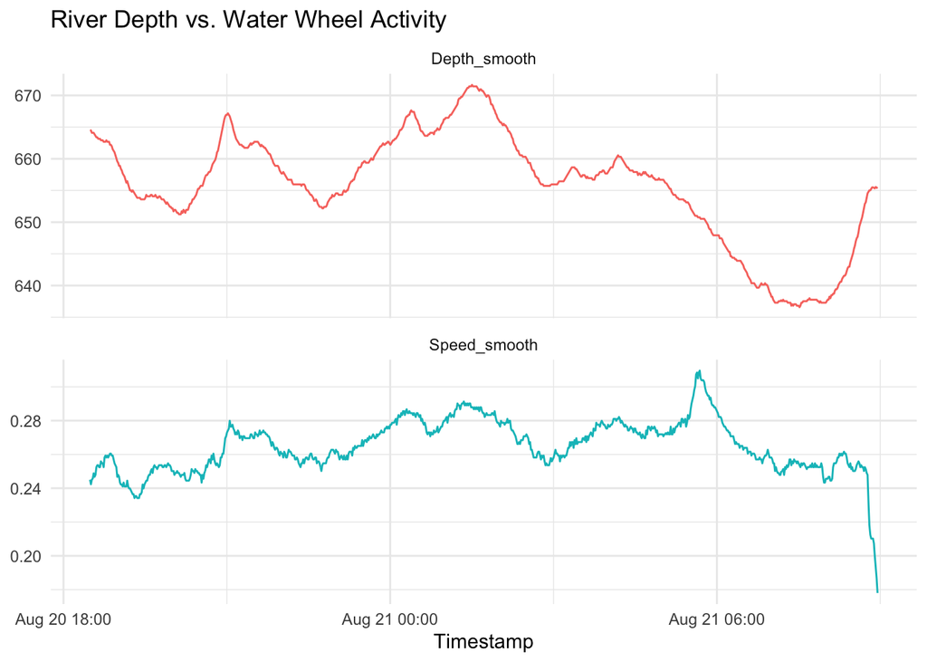

```r
#Smooth datapoints over a 10min period
Interval_Pulses_smooth <- slide_index_dbl(
  data$Interval_Pulses,
  data$Timestamp,
  mean,
  .before = minutes(5),
  .after = minutes(5)
)

Speed_smooth <- slide_index_dbl(
  data$Speed,
  data$Timestamp,
  mean,
  .before = minutes(5),
  .after = minutes(5)
)

Depth_mm_smooth <- slide_index_dbl(
  data$Depth_mm,
  data$Timestamp,
  mean,
  .before = minutes(5),
  .after = minutes(5)
)

data$Interval_smooth <- Interval_Pulses_smooth
data$Speed_smooth <- Speed_smooth
data$Depth_smooth <- Depth_mm_smooth

# Pivot long and create stacked line charts
data %>%
  pivot_longer(cols = c(Speed_smooth, Depth_smooth),
               names_to = "Metric",
               values_to = "Value") %>%
  ggplot(aes(x = Timestamp, y = Value, color = Metric)) +
  geom_line(show.legend = FALSE) +
  facet_wrap(~ Metric, scales = "free_y", ncol = 1) +
  labs(
    title = "River Depth vs. Water Wheel Activity",
    x = "Timestamp",
    y = NULL
  ) +
  theme_minimal()
```

### Include manually exported rain data in 10min timesteps and plot:

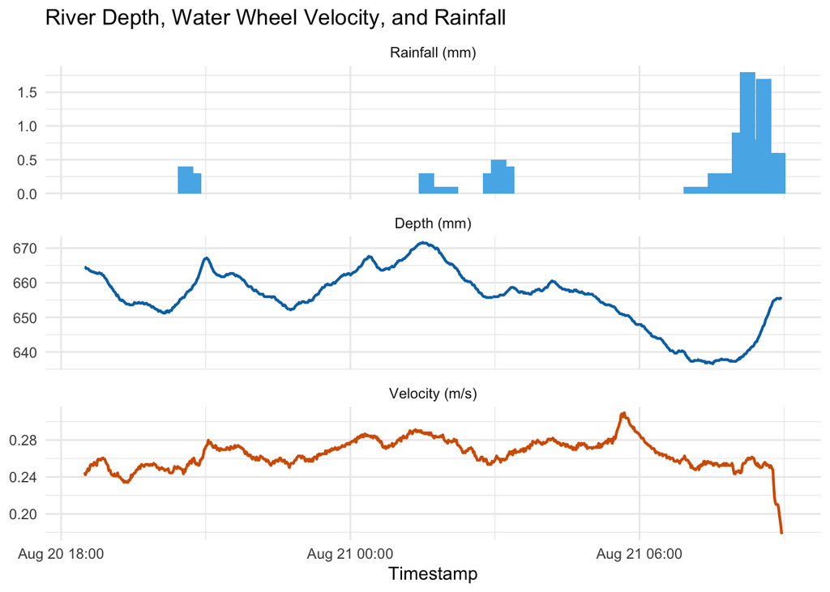

```r
# Manual rain entries (mm)
rain_manual <- tribble(
  ~time_str, ~Rain_mm,
  "2026-08-20 20:30:00", 0.4,
  "2026-08-20 20:40:00", 0.3,
  "2026-08-21 01:30:00", 0.3,
  "2026-08-21 01:40:00", 0.1,
  "2026-08-21 01:50:00", 0.1,
  "2026-08-21 02:00:00", 0.1,
  "2026-08-21 02:50:00", 0.3,
  "2026-08-21 03:00:00", 0.5,
  "2026-08-21 03:10:00", 0.4,
  "2026-08-21 07:00:00", 0.1,
  "2026-08-21 07:10:00", 0.1,
  "2026-08-21 07:20:00", 0.1,
  "2026-08-21 07:30:00", 0.3,
  "2026-08-21 07:40:00", 0.3,
  "2026-08-21 07:50:00", 0.3,
  "2026-08-21 08:00:00", 0.9,
  "2026-08-21 08:10:00", 1.8,
  "2026-08-21 08:20:00", 0.8,
  "2026-08-21 08:30:00", 1.7,
  "2026-08-21 08:40:00", 0.6,
  "2026-08-21 08:50:00", 0.6
)

rain_manual$Timestamp <- ymd_hms(rain_manual$time_str)

# Floor timestamps to matching 10-min blocks and join rain
data <- data %>%
  mutate(Timestamp_10m = floor_date(Timestamp, "10 minutes")) %>%
  left_join(rain_manual, by = c("Timestamp_10m" = "Timestamp")) %>%
  mutate(Rain_mm = replace_na(Rain_mm, 0)) # Fill missing rain intervals with 0

# Assign the smoothed vectors into the data frame as columns
data$Interval_Pulses_smooth <- Interval_Pulses_smooth
data$Speed_smooth <- Speed_smooth
data$Depth_mm_smooth <- Depth_mm_smooth

# Run the plot prep
data_plot <- data %>%
  select(Timestamp, Speed_smooth, Depth_mm_smooth, Rain_mm) %>%
  pivot_longer(
    cols = c(Speed_smooth, Depth_mm_smooth, Rain_mm),
    names_to = "Metric",
    values_to = "Value"
  ) %>%
  mutate(Metric = factor(Metric,
                         levels = c("Rain_mm", "Depth_mm_smooth", "Speed_smooth"),
                         labels = c("Rainfall (mm)", "Depth (mm)", "Velocity (m/s)")))

# Render the plot
ggplot() +
  geom_col(
    data = filter(data_plot, Metric == "Rainfall (mm)"),
    aes(x = Timestamp, y = Value),
    fill = "#56B4E9",
    width = 600
  ) +
  geom_line(
    data = filter(data_plot, Metric != "Rainfall (mm)"),
    aes(x = Timestamp, y = Value, color = Metric),
    linewidth = 0.8,
    show.legend = FALSE
  ) +
  facet_wrap(~ Metric, scales = "free_y", ncol = 1) +
  scale_color_manual(values = c("Depth (mm)" = "#0072B2", "Velocity (m/s)" = "#D55E00")) +
  labs(
    title = "River Depth, Water Wheel Velocity, and Rainfall",
    x = "Timestamp",
    y = NULL
  ) +
  theme_minimal()
```

### Plot density distributions for the whole time period and before the big deviation (likely due to a mechanical issue with the wheel):

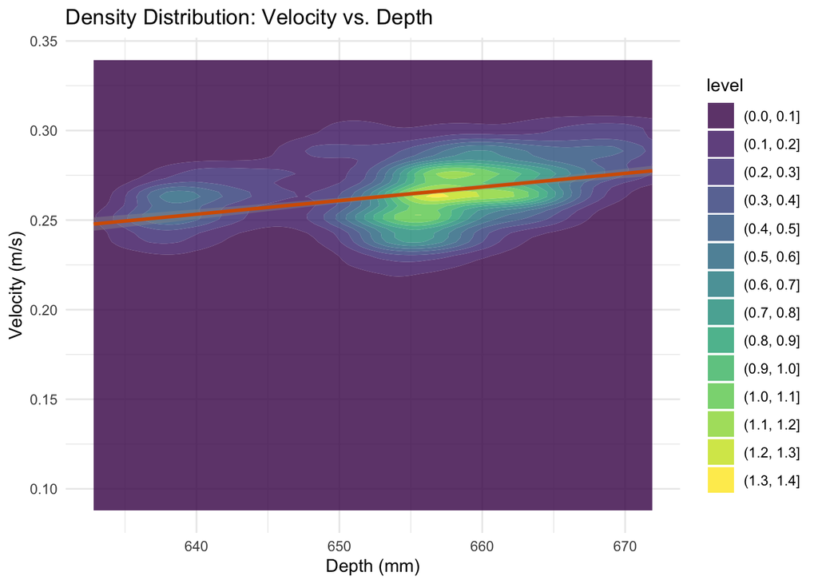

```r
#Original data
ggplot(data, aes(x = Depth_mm, y = Speed)) +
  geom_density_2d_filled(alpha = 0.8) +
  geom_smooth(method = "lm", color = "#D55E00", se = TRUE) +
  labs(title = "Density Distribution: Velocity vs. Depth", x = "Depth (mm)", y = "Velocity (m/s)") +
  theme_minimal()
```

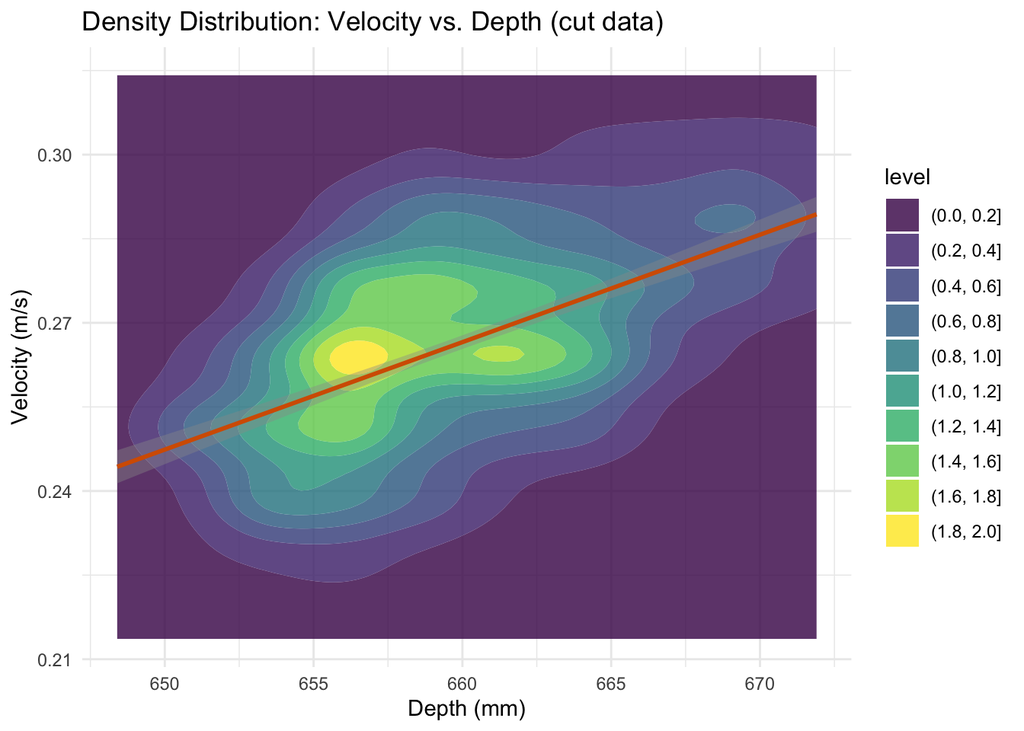

```r
data_cut <- data[1:632,]

#Data before the deviation
ggplot(data_cut, aes(x = Depth_mm, y = Speed)) +
  geom_density_2d_filled(alpha = 0.8) +
  geom_smooth(method = "lm", color = "#D55E00", se = TRUE) +
  labs(title = "Density Distribution: Velocity vs. Depth (cut data)", x = "Depth (mm)", y = "Velocity (m/s)") +
  theme_minimal()
```

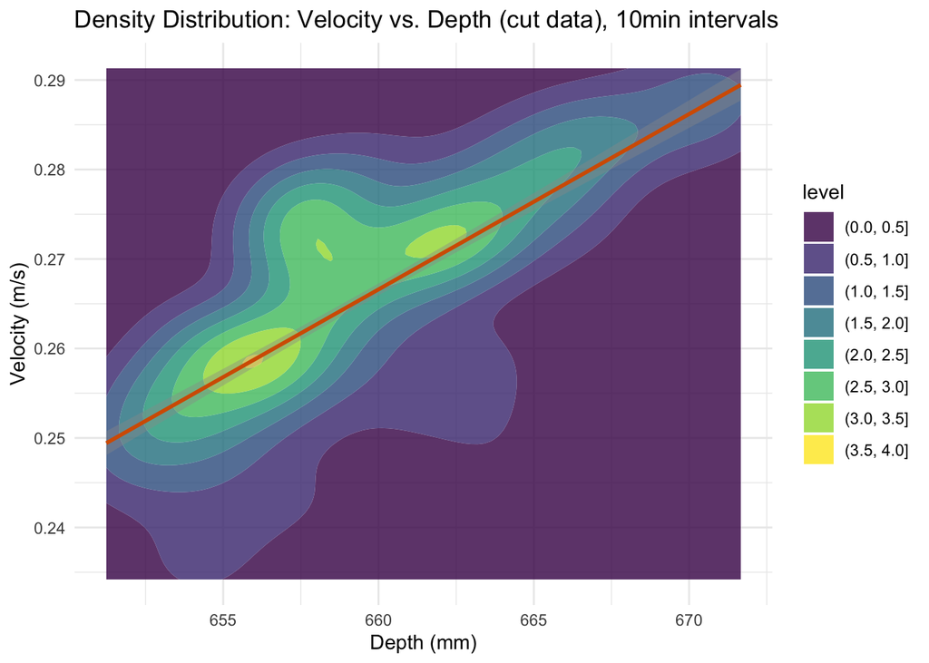

```r
#Data before the deviation and smoothed
ggplot(data_cut, aes(x = Depth_mm_smooth, y = Speed_smooth)) +
  geom_density_2d_filled(alpha = 0.8) +
  geom_smooth(method = "lm", color = "#D55E00", se = TRUE) +
  labs(title = "Density Distribution: Velocity vs. Depth (cut data), 10min intervals", x = "Depth (mm)", y = "Velocity (m/s)") +
  theme_minimal()
```

### Fit linear model between pressure and flow velocity and output key values

```r
# Fit the linear model (y ~ x)
fit <- lm(Interval_Pulses ~ Depth_mm, data = data)
fit_cut <- lm(Interval_Pulses ~ Depth_mm, data = data_cut)
fit_smooth <- lm(Interval_Pulses_smooth ~ Depth_mm_smooth, data = data)
fit_smooth_cut <- lm(Interval_Pulses_smooth ~ Depth_mm_smooth, data = data_cut)

# View the full statistical output (includes p-value, R-squared, and coefficients)
glance(fit)[, c("r.squared", "p.value")] #Original data
```

```
## # A tibble: 1 × 2
##   r.squared  p.value
##       <dbl>    <dbl>
## 1    0.0991 1.90e-21
```

```r
glance(fit_cut)[, c("r.squared", "p.value")] #Data before deviation
```

```
## # A tibble: 1 × 2
##   r.squared  p.value
##       <dbl>    <dbl>
## 1     0.288 1.73e-48
```

```r
glance(fit_smooth)[, c("r.squared", "p.value")] #Data smoothed 10min
```

```
## # A tibble: 1 × 2
##   r.squared  p.value
##       <dbl>    <dbl>
## 1     0.174 6.70e-38
```

```r
glance(fit_smooth_cut)[, c("r.squared", "p.value")] #Data before deviation smoothed 10min
```

```
## # A tibble: 1 × 2
##   r.squared   p.value
##       <dbl>     <dbl>
## 1     0.562 4.09e-115
```

## Appendices

### Full code for Arduino 1 (Water wheel)

```
#include <SPI.h>  // Communicate with SPI devices
#include <SD.h>   // SD Card support
#include <Wire.h>     // Communicate with I2C devices
#include <RTClib.h>   // Adafruit RTClib for RTC Clock
#include <U8g2lib.h>  // Display library for Seeed Expansion Board

#define BUTTON_PIN D0    // Pin the reed switch is connected to (besides ground)
#define PULSE_OUT_PIN D3    // Signal output pin to secondary Arduino
#define SD_CS_PIN D2        // SD CS pin on Seeed Expansion Board

// ----------------------------------------------------
// WATER WHEEL CONFIGURATION
// ----------------------------------------------------
const float WHEEL_RADIUS_M = 0.12;     // Wheel radius in meters
const float WHEEL_EFFICIENCY = 0.85;   // Factor 0.0 - 1.0 (Not used as we did not calibrate due to time constraints)
// ----------------------------------------------------

RTC_PCF8563 rtc;    // Initialise the RTC chip
U8G2_SSD1306_128X64_NONAME_F_HW_I2C u8g2(U8G2_R0, /* reset=*/ U8X8_PIN_NONE);   // Initialise the OLED display

// Volatile variables shared with the Interrupt Service Routine (ISR)
volatile unsigned long intervalPulses = 0;  // Pulses in current 1-minute window
volatile unsigned long totalPulses = 0;     // Total switch pulses over runtime
volatile unsigned long lastPulseTime = 0;   // Timestamp of last valid pulse
volatile unsigned long pulseDelta = 0;       // Time between last two pulses (ms)
volatile bool newPulseDetected = false;

// Sequential measurement index for each minute
unsigned long measurementNum = 0;

// Calculated Real-time speed
float currentRpm = 0.0;

// Timing intervals
unsigned long lastLogTime = 0;
const unsigned long LOG_INTERVAL = 60000; // Set how long an interval takes (1min in this case)

unsigned long lastOledUpdate = 0;
const unsigned long OLED_INTERVAL = 200;  // Refresh screen every 200ms

```

[output cut: 155 more lines]

```
    // Seconds until SD Save & Sync Pulse
    u8g2.setCursor(0, 50);
    u8g2.print("Next Sync: ");
    u8g2.print(secondsRemaining);
    u8g2.print("s");

    // Estimated Water Speed
    u8g2.setCursor(0, 62);
    u8g2.print("Est. Flow: ");
    u8g2.print(waterSpeedMs, 2);
    u8g2.print(" m/s");

    u8g2.sendBuffer();
  }
}
```

### Full code for Arduino 2 (Pressure sensor)

```
#include <Wire.h>             // Communicate with I2C devices
#include <DFRobot_ADS1115.h>  // Library for the ADC
#include <U8g2lib.h>          // Display library for Seeed Expansion Board
#include <RTClib.h>           // Adafruit RTClib
#include <SPI.h>              // Communicate with SPI devices
#include <SD.h>               // SD Card support

#define TRIGGER_PIN D3   // Pin that receives the input from Arduino 1
#define SD_CS_PIN D2     // SD CS pin on Seeed Expansion Board

RTC_PCF8563 rtc;         // Initialise the RTC chip

#define RANGE 5000       // Maximum depth of Sensor
#define VREF 3300        // Reference voltage of Arduino
#define CURRENT_INIT 4   // Initial current at 0 depth
#define DENSITY_WATER 1  // Water density (temp. dependent)

DFRobot_ADS1115 ads(&Wire); // Initialise ADC
U8G2_SSD1306_128X64_NONAME_F_HW_I2C u8g2(U8G2_R0, /* reset=*/ U8X8_PIN_NONE); // Initialise the OLED display

// Set initial values
int16_t dataVoltage = 0; // Voltage from the ADC
float dataCurrent = 0.0; // Current derived from voltage
float depth = 0.0;       // Water depth
unsigned long measurementNum = 0; // Sequential measurement index

// Interrupt flags
volatile bool pulseTriggered = false;

unsigned long lastSyncMillis = 0; // Time since last sync
bool hasSynced = false;

unsigned long lastOledUpdate = 0;
const unsigned long OLED_INTERVAL = 200; // Display update frequency

// Hardware Interrupt Service Routine (ISR)
void pulseISR() {
  pulseTriggered = true;
}

```

[output cut: 123 more lines]

```
    u8g2.print("Volt: ");
    u8g2.print(dataVoltage);
    u8g2.print("mV ");
    u8g2.print(dataCurrent, 1);
    u8g2.print("mA");

    u8g2.setFont(u8g2_font_7x14B_tf);
    u8g2.setCursor(0, 56);
    u8g2.print("Depth: ");
    u8g2.print(depth, 1);
    u8g2.print(" mm");

    u8g2.sendBuffer();
  }
}
```